# Python Project - (Dataset Exploration Title)

### What features in the dataset do you think will help support your investigation into your feature(s) of interest?

```python
# culumns needed for analysis
s_columns = ['ListingKey', 'ListingNumber', 'LoanStatus', 'ListingCategory (numeric)', 'BorrowerState','Occupation',
             'EmploymentStatus', 'IsBorrowerHomeowner', 'CurrentlyInGroup', 'IncomeRange', 'LoanOriginalAmount',
             'LoanOriginationDate', 'Recommendations', 'Term', 'StatedMonthlyIncome']
  # to cofirm length of the selected columns
len(s_columns)
```

```
15
```

```python
# assigning the selected columns to a value
loan_df = loan_df[s_columns]
```

```python
loan_df
```

|  | ListingKey | ListingNumber | LoanStatus | ListingCategory (numeric) | BorrowerState | Occupation | EmploymentStatus | IsBorrowerHomeowner | CurrentlyInGroup | IncomeRange | LoanOriginalAmount | LoanOriginationDate | Recommendations | Term | StatedMonthlyIncome |
| --- | --- | --- | --- | --- | --- | --- | --- | --- | --- | --- | --- | --- | --- | --- | --- |
| 0 | 1021339766868145413AB3B | 193129 | Completed | 0 | CO | Other | Self-employed | True | True | $25,000-49,999 | 9425 | 12/09/2007 00:00 | 0 | 36 | 3083.333333 |
| 1 | 10273602499503308B223C1 | 1209647 | Current | 2 | CO | Professional | Employed | False | False | $50,000-74,999 | 10000 | 03/03/2014 00:00 | 0 | 36 | 6125.000000 |
| 2 | 0EE9337825851032864889A | 81716 | Completed | 0 | GA | Other | Not available | False | True | Not displayed | 3001 | 17/01/2007 00:00 | 0 | 36 | 2083.333333 |
| 3 | 0EF5356002482715299901A | 658116 | Current | 16 | GA | Skilled Labor | Employed | True | False | $25,000-49,999 | 10000 | 01/11/2012 00:00 | 0 | 36 | 2875.000000 |
| 4 | 0F023589499656230C5E3E2 | 909464 | Current | 2 | MN | Executive | Employed | True | False | $100,000+ | 15000 | 20/09/2013 00:00 | 0 | 36 | 9583.333333 |
| ... | ... | ... | ... | ... | ... | ... | ... | ... | ... | ... | ... | ... | ... | ... | ... |
| 113932 | E6D9357655724827169606C | 753087 | Current | 1 | IL | Food Service Management | Employed | True | False | $50,000-74,999 | 10000 | 22/04/2013 00:00 | 0 | 36 | 4333.333333 |
| 113933 | E6DB353036033497292EE43 | 537216 | FinalPaymentInProgress | 7 | PA | Professional | Employed | True | False | $75,000-99,999 | 2000 | 07/11/2011 00:00 | 0 | 36 | 8041.666667 |
| 113934 | E6E13596170052029692BB1 | 1069178 | Current | 1 | TX | Other | Employed | True | False | $25,000-49,999 | 10000 | 23/12/2013 00:00 | 0 | 60 | 2875.000000 |
| 113935 | E6EB3531504622671970D9E | 539056 | Completed | 2 | GA | Food Service | Full-time | True | False | $25,000-49,999 | 15000 | 21/11/2011 00:00 | 0 | 60 | 3875.000000 |
| 113936 | E6ED3600409833199F711B7 | 1140093 | Current | 1 | NY | Professor | Employed | False | False | $50,000-74,999 | 2000 | 21/01/2014 00:00 | 0 | 36 | 4583.333333 |

113937 rows × 15 columns

## Data Assessment

> > To examine the subsetted data for exploratory data analysis.

```python
# to check the shape of the subset dataframe
loan_df.info()
```

[output not shown]

```python
# to check the shape of the subset dataframe
loan_df.info()
```

```
<class 'pandas.core.frame.DataFrame'>
RangeIndex: 113937 entries, 0 to 113936
Data columns (total 15 columns):
 #   Column                     Non-Null Count   Dtype
---  ------                     --------------   -----
 0   ListingKey                 113937 non-null  object
 1   ListingNumber              113937 non-null  int64
 2   LoanStatus                 113937 non-null  object
 3   ListingCategory (numeric)  113937 non-null  int64
 4   BorrowerState              108422 non-null  object
 5   Occupation                 110349 non-null  object
 6   EmploymentStatus           111682 non-null  object
 7   IsBorrowerHomeowner        113937 non-null  bool
 8   CurrentlyInGroup           113937 non-null  bool
 9   IncomeRange                113937 non-null  object
 10  LoanOriginalAmount         113937 non-null  int64
 11  LoanOriginationDate        113937 non-null  object
 12  Recommendations            113937 non-null  int64
 13  Term                       113937 non-null  int64
 14  StatedMonthlyIncome        113937 non-null  float64
dtypes: bool(2), float64(1), int64(5), object(7)
memory usage: 11.5+ MB
```

```python
# to look at columns of the selected columns
loan_df.columns
```

```
Index(['ListingKey', 'ListingNumber', 'LoanStatus',
       'ListingCategory (numeric)', 'BorrowerState', 'Occupation',
       'EmploymentStatus', 'IsBorrowerHomeowner', 'CurrentlyInGroup',
       'IncomeRange', 'LoanOriginalAmount', 'LoanOriginationDate',
       'Recommendations', 'Term', 'StatedMonthlyIncome'],
      dtype='object')
```

### Definition of the selected columns

### Definition of the selected columns

> ListingKey: Unique key for each listing, same value as the 'key' used in the listing object in the API.

> ListingNumber: The number that uniquely identifies the listing to the public as displayed on the website.

> LoanStatus: The current status of the loan: Cancelled, Chargedoff, Completed, Current, Defaulted, FinalPaymentInProgress, PastDue. The PastDue status will be accompanied by a delinquency bucket.

> ListingCategory (numeric): The category of the listing that the borrower selected when posting their listing: 0 - Not Available, 1 - Debt Consolidation, 2 - Home Improvement, 3 - Business, 4 - Personal Loan, 5 - Student Use, 6 - Auto, 7- Other, 8 - Baby&Adoption, 9 - Boat, 10 - Cosmetic Procedure, 11 - Engagement Ring, 12 - Green Loans, 13 - Household Expenses, 14 - Large Purchases, 15 - Medical/Dental, 16 - Motorcycle, 17 - RV, 18 - Taxes, 19 - Vacation, 20 - Wedding Loans

> BorrowerState: The two letter abbreviation of the state of the address of the borrower at the time the Listing was created.

> Occupation: The Occupation selected by the Borrower at the time they created the listing.

> EmploymentStatus: The employment status of the borrower at the time they posted the listing.

> IsBorrowerHomeowner: A Borrower will be classified as a homowner if they have a mortgage on their credit profile or provide documentation confirming they are a homeowner.

> CurrentlyInGroup: Specifies whether or not the Borrower was in a group at the time the listing was created.

> IncomeRange: The income range of the borrower at the time the listing was created.

> LoanOriginalAmount:The origination amount of the loan.

> LoanOriginationDate:The date the loan was originated.

> Recommendations: Number of recommendations the borrower had at the time the listing was created.

> StatedMonthlyIncome: The monthly income the borrower stated at the time the listing was created.

```python
# to check the head of the data
loan_df.head()
```

|  | ListingKey | ListingNumber | LoanStatus | ListingCategory (numeric) | BorrowerState | Occupation | EmploymentStatus | IsBorrowerHomeowner | CurrentlyInGroup | IncomeRange | LoanOriginalAmount | LoanOriginationDate | Recommendations | Term | StatedMonthlyIncome |
| --- | --- | --- | --- | --- | --- | --- | --- | --- | --- | --- | --- | --- | --- | --- | --- |
| 0 | 1021339766868145413AB3B | 193129 | Completed | 0 | CO | Other | Self-employed | True | True | $25,000-49,999 | 9425 | 12/09/2007 00:00 | 0 | 36 | 3083.333333 |
| 1 | 10273602499503308B223C1 | 1209647 | Current | 2 | CO | Professional | Employed | False | False | $50,000-74,999 | 10000 | 03/03/2014 00:00 | 0 | 36 | 6125.000000 |
| 2 | 0EE9337825851032864889A | 81716 | Completed | 0 | GA | Other | Not available | False | True | Not displayed | 3001 | 17/01/2007 00:00 | 0 | 36 | 2083.333333 |
| 3 | 0EF5356002482715299901A | 658116 | Current | 16 | GA | Skilled Labor | Employed | True | False | $25,000-49,999 | 10000 | 01/11/2012 00:00 | 0 | 36 | 2875.000000 |
| 4 | 0F023589499656230C5E3E2 | 909464 | Current | 2 | MN | Executive | Employed | True | False | $100,000+ | 15000 | 20/09/2013 00:00 | 0 | 36 | 9583.333333 |

```python
# to check information about our new data
loan_df.info()
```

```
<class 'pandas.core.frame.DataFrame'>
RangeIndex: 113937 entries, 0 to 113936
Data columns (total 15 columns):
 #   Column                     Non-Null Count   Dtype
---  ------                     --------------   -----
 0   ListingKey                 113937 non-null  object
 1   ListingNumber              113937 non-null  int64
 2   LoanStatus                 113937 non-null  object
 3   ListingCategory (numeric)  113937 non-null  int64
 4   BorrowerState              108422 non-null  object
 5   Occupation                 110349 non-null  object
 6   EmploymentStatus           111682 non-null  object
 7   IsBorrowerHomeowner        113937 non-null  bool
 8   CurrentlyInGroup           113937 non-null  bool
 9   IncomeRange                113937 non-null  object
 10  LoanOriginalAmount         113937 non-null  int64
 11  LoanOriginationDate        113937 non-null  object
 12  Recommendations            113937 non-null  int64
 13  Term                       113937 non-null  int64
 14  StatedMonthlyIncome        113937 non-null  float64
dtypes: bool(2), float64(1), int64(5), object(7)
memory usage: 11.5+ MB
```

```python
# Returns the number of unique in the dataset
loan_df.nunique()
```

```
ListingKey                   113048
ListingNumber                113066
LoanStatus                       12
ListingCategory (numeric)        21
BorrowerState                    51
Occupation                       67
EmploymentStatus                  8
IsBorrowerHomeowner               2
CurrentlyInGroup                  2
IncomeRange                       8
LoanOriginalAmount             2468
LoanOriginationDate            1873
Recommendations                  17
Term                              3
StatedMonthlyIncome           13502
dtype: int64
```

```python
# to check for number of duplicate records
sum(loan_df.duplicated())
```

```
871
```

> There are 871 records that are duplicated. Before determining the course of action for handling them, my initial step involves examining all the duplicate records in the 'ListingKey' and 'ListingNumber'colunms to identify any discernible patterns.

```python
# to check if there are duplicate listingkey records
sum(loan_df['ListingKey'].duplicated())
```

```
889
```

```python
# to check if there are duplicate 'ListingNumber' records
sum(loan_df['ListingNumber'].duplicated())
```

```
871
```

```python
# to observe the duplicate records
loan_df[loan_df[['ListingKey', 'ListingNumber']].duplicated(keep = False)]
```

|  | ListingKey | ListingNumber | LoanStatus | ListingCategory (numeric) | BorrowerState | Occupation | EmploymentStatus | IsBorrowerHomeowner | CurrentlyInGroup | IncomeRange | LoanOriginalAmount | LoanOriginationDate | Recommendations | Term | StatedMonthlyIncome |
| --- | --- | --- | --- | --- | --- | --- | --- | --- | --- | --- | --- | --- | --- | --- | --- |
| 8 | 0F043596202561788EA13D5 | 1023355 | Current | 7 | IL | Food Service | Employed | True | False | $25,000-49,999 | 10000 | 12/12/2013 00:00 | 0 | 36 | 3333.333333 |
| 9 | 0F043596202561788EA13D5 | 1023355 | Current | 7 | IL | Food Service | Employed | True | False | $25,000-49,999 | 10000 | 12/12/2013 00:00 | 0 | 36 | 3333.333333 |
| 29 | 0F563597161095613517437 | 1051243 | Current | 1 | LA | Other | Employed | True | False | $100,000+ | 35000 | 16/01/2014 00:00 | 0 | 36 | 10416.666670 |
| 176 | 106335993636414276CB477 | 1119836 | Current | 3 | WA | Sales - Commission | Employed | False | False | $75,000-99,999 | 4000 | 16/01/2014 00:00 | 0 | 36 | 6250.000000 |
| 313 | 09233589620788733CFB8CE | 930842 | Current | 1 | KY | Professional | Self-employed | True | False | $100,000+ | 15000 | 18/11/2013 00:00 | 0 | 36 | 13333.333330 |
| ... | ... | ... | ... | ... | ... | ... | ... | ... | ... | ... | ... | ... | ... | ... | ... |
| 113548 | FB6A35999320129979DBBA3 | 1158474 | Current | 18 | CO | Other | Employed | True | False | $75,000-99,999 | 14000 | 04/03/2014 00:00 | 0 | 60 | 7666.666667 |
| 113636 | D9BF3589576999233477E75 | 904020 | Current | 1 | WI | NaN | Other | True | False | $25,000-49,999 | 4000 | 12/11/2013 00:00 | 0 | 36 | 2500.000000 |
| 113733 | E2303594522341016B8EE15 | 1002326 | Current | 1 | WI | Skilled Labor | Employed | False | False | $50,000-74,999 | 10000 | 13/11/2013 00:00 | 0 | 60 | 4583.333333 |
| 113773 | DE8535960513435199406CE | 1056749 | Current | 1 | NJ | Other | Employed | True | False | $25,000-49,999 | 10000 | 23/12/2013 00:00 | 0 | 36 | 2720.833333 |
| 113863 | C74335893905744205D4056 | 928893 | Current | 1 | NH | Principal | Employed | False | False | $25,000-49,999 | 6500 | 22/11/2013 00:00 | 0 | 36 | 3333.333333 |

1698 rows × 15 columns

Upon examining entries with duplicate ListingKey and ListingNumber, I noticed that corresponding columns, like ListingCreationDate and BorrowerAPR, share identical values for each duplicate record. Consequently, I intend to eliminate these redundant records.

```python
# to get rid of duplicates records
loan_df.drop_duplicates(subset='ListingKey', keep='first', inplace=True)
```

```python
# To assess the dataframe further
loan_df.dtypes
```

```
ListingKey                    object
ListingNumber                  int64
LoanStatus                    object
ListingCategory (numeric)      int64
BorrowerState                 object
Occupation                    object
EmploymentStatus              object
IsBorrowerHomeowner             bool
CurrentlyInGroup                bool
IncomeRange                   object
LoanOriginalAmount             int64
LoanOriginationDate           object
Recommendations                int64
Term                           int64
StatedMonthlyIncome          float64
dtype: object
```

The ListingCategory has been encoded.

The encoding for ListingCategory is as follows: 0 - Not Available, 1 - Debt Consolidation, 2 - Home Improvement, 3 - Business, 4 - Personal Loan, 5 - Student Use, 6 - Auto, 7 - Other, 8 - Baby & Adoption, 9 - Boat, 10 - Cosmetic Procedure, 11 - Engagement Ring, 12 - Green Loans, 13 - Household Expenses, 14 - Large Purchases, 15 - Medical/Dental, 16 - Motorcycle, 17 - RV, 18 - Taxes, 19 - Vacation, 20 - Wedding Loans.

A new column will be created to decode the ListingCategory encoding.

```python
# decoding Listing Category
category = {0: "Not Available", 1: "Debt Consolidation", 2: "Home Improvement", 3: "Business", 4: "Personal Loan",
            5: "Student Use", 6: "Auto", 7: "Other", 8: "Baby&Adoption", 9: "Boat", 10: "Cosmetic Procedure",
            11: "Engagement Ring", 12: "Green Loans", 13: "Household Expenses", 14: "Large Purchases", 15: "Medical/Dental",
            16: "Motorcycle", 17: "RV", 18: "Taxes", 19: "Vacation", 20: "Wedding Loans"}

# the column used to encode listing category
loan_df['ListingCategory'] = loan_df['ListingCategory (numeric)'].replace(category)
```

```python
# to check the unique values in ListingCategory to be sure all the changes were made
loan_df['ListingCategory'].unique()
```

```
array(['Not Available', 'Home Improvement', 'Motorcycle',
       'Debt Consolidation', 'Other', 'Household Expenses', 'Auto',
       'Medical/Dental', 'Wedding Loans', 'Vacation', 'Business', 'Taxes',
       'Baby&Adoption', 'Personal Loan', 'Engagement Ring',
       'Large Purchases', 'Student Use', 'Boat', 'RV',
       'Cosmetic Procedure', 'Green Loans'], dtype=object)
```

> The "LoanOriginationDate" column is and object and should be in time date format

```python
# to change LoanOriginationDate to time and date format
loan_df['LoanOriginationDate'] = pd.to_datetime(loan_df['LoanOriginationDate'], format="%d/%m/%Y %H:%M")
```

```python
# to check for null values in each columns
null = loan_df.isna().sum()
print(null)
```

```
ListingKey                      0
ListingNumber                   0
LoanStatus                      0
ListingCategory (numeric)       0
BorrowerState                5514
Occupation                   3527
EmploymentStatus             2253
IsBorrowerHomeowner             0
CurrentlyInGroup                0
IncomeRange                     0
LoanOriginalAmount              0
LoanOriginationDate             0
Recommendations                 0
Term                            0
StatedMonthlyIncome             0
ListingCategory                 0
dtype: int64
```

Decided to drop all null rows from the dataset

```python
# to drop null rows in the BorrowerState colunm
loan_df.dropna(subset=['BorrowerState'], inplace=True)
```

```python
# to drop null rows in the Occupation colunm
loan_df.dropna(subset=['Occupation'], inplace=True)
```

```python
# to drop null rows in the EmploymentStatus  colunm
loan_df.dropna(subset=['EmploymentStatus'], inplace=True)
```

```python
# To confirm if all null rows were dropped
null = loan_df.isna().sum()
print(null)
```

```
ListingKey                   0
ListingNumber                0
LoanStatus                   0
ListingCategory (numeric)    0
BorrowerState                0
Occupation                   0
EmploymentStatus             0
IsBorrowerHomeowner          0
CurrentlyInGroup             0
IncomeRange                  0
LoanOriginalAmount           0
LoanOriginationDate          0
Recommendations              0
Term                         0
StatedMonthlyIncome          0
ListingCategory              0
dtype: int64
```

To check the descriptive statistics of the numerical columns in the dataframe

```python
loan_df.describe()
```

|  | ListingNumber | ListingCategory (numeric) | LoanOriginalAmount | LoanOriginationDate | Recommendations | Term | StatedMonthlyIncome |
| --- | --- | --- | --- | --- | --- | --- | --- |
| count | 1.053930e+05 | 105393.000000 | 105393.000000 | 105393 | 105393.000000 | 105393.000000 | 1.053930e+05 |
| mean | 6.532859e+05 | 2.950054 | 8504.650973 | 2011-10-14 20:58:06.971620608 | 0.048846 | 41.093621 | 5.677273e+03 |
| min | 2.148700e+04 | 0.000000 | 1000.000000 | 2006-07-03 00:00:00 | 0.000000 | 12.000000 | 0.000000e+00 |
| 25% | 4.537350e+05 | 1.000000 | 4000.000000 | 2010-04-29 00:00:00 | 0.000000 | 36.000000 | 3.303583e+03 |
| 50% | 6.141010e+05 | 1.000000 | 7000.000000 | 2012-07-31 00:00:00 | 0.000000 | 36.000000 | 4.750000e+03 |
| 75% | 8.938380e+05 | 3.000000 | 12000.000000 | 2013-09-18 00:00:00 | 0.000000 | 36.000000 | 6.916667e+03 |
| max | 1.255725e+06 | 20.000000 | 35000.000000 | 2014-03-12 00:00:00 | 39.000000 | 60.000000 | 1.750003e+06 |
| std | 3.043497e+05 | 4.062098 | 6274.842836 | NaN | 0.337749 | 10.674496 | 7.674857e+03 |

## Univariate Exploration

> Analyzing a single variable is known as univariate analysis. This approach is used to explore the distribution of values for a specific individual variable.

### Question

What is the count of borrower per state?

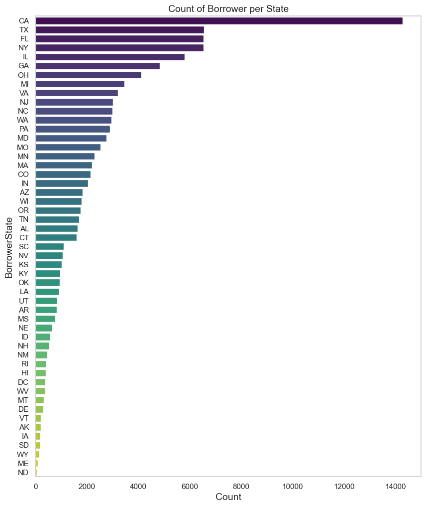

```python
counts = loan_df['BorrowerState'].value_counts().sort_values(ascending=False)
count_df = pd.DataFrame({'BorrowerState': counts.index, 'Count': counts.values})

sns.set(style="whitegrid")
plt.figure(figsize=(10, 12))

ax = sns.barplot(y='BorrowerState', x='Count', data=count_df, palette='viridis')

# Add labels and title
plt.ylabel('BorrowerState', fontsize = 14)
plt.xlabel('Count', fontsize = 14)
plt.title('Count of Borrower per State', fontsize = 14)

ax.grid(False, axis='both')
```

### Question

> Count of borrower per employment status

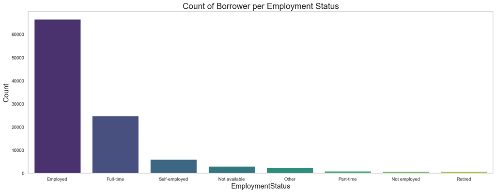

```python
counts = loan_df['EmploymentStatus'].value_counts().sort_values(ascending=False)
count_df = pd.DataFrame({'EmploymentStatus': counts.index, 'Count': counts.values})

sns.set(style="whitegrid")
plt.figure(figsize=(20, 7))

ax = sns.barplot(x='EmploymentStatus', y='Count', data=count_df, palette='viridis')

# Add labels and title
plt.xlabel('EmploymentStatus', fontsize = 17)
plt.ylabel('Count', fontsize = 17)
plt.title('Count of Borrower per Employment Status', fontsize = 20)

ax.grid(False, axis='both')
```

Observation: Most of the Borrowers are Employed.

### Question

> What is the percentage of borrowers who owned a house?

```
IsBorrowerHomeowner
True     54434
False    50959
Name: count, dtype: int64
```

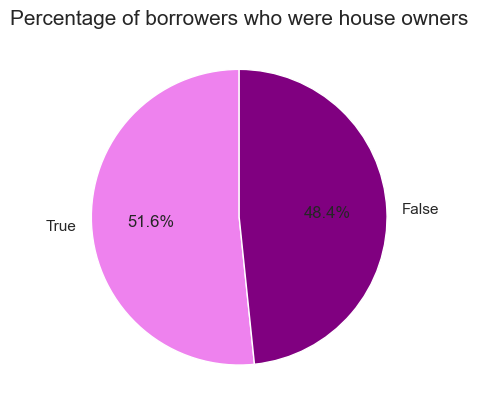

```python
# Count the occurrences of each category
category_counts = loan_df['IsBorrowerHomeowner'].value_counts()

# Create a pie chart using Matplotlib
plt.pie(category_counts, labels=category_counts.index, autopct='%1.1f%%', startangle=90, colors=['violet', 'purple', 'lightcoral'])

# Add a title
plt.title('Percentage of borrowers who were house owners', fontsize=15)

loan_df['IsBorrowerHomeowner'].value_counts()
```

Observation: Most of the Borrowers owned a house.

### Question:

What percentage of Borrowers are in each listing category?

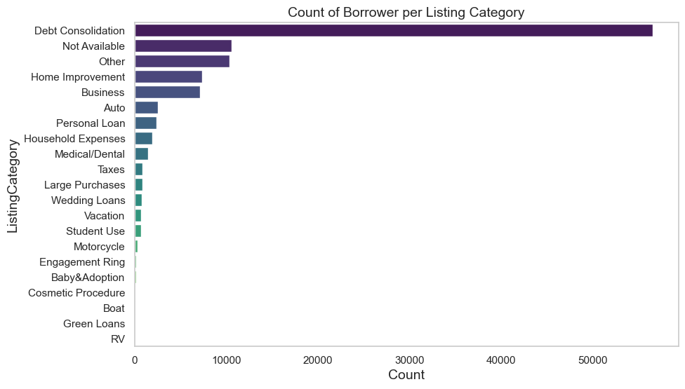

```python
counts = loan_df['ListingCategory'].value_counts().sort_values(ascending=False)
count_df = pd.DataFrame({'ListingCategory': counts.index, 'Count': counts.values})

sns.set(style="whitegrid")
plt.figure(figsize=(10, 6))

ax = sns.barplot(y='ListingCategory', x='Count', data=count_df, palette='viridis')

# Add labels and title
plt.ylabel('ListingCategory', fontsize = 14)
plt.xlabel('Count', fontsize = 14)
plt.title('Count of Borrower per Listing Category', fontsize = 14)

ax.grid(False, axis='both')
```

### Observation

> Most of the Borrowers fall into the Debt Consolidation Category

## Bivariate Exploration

> As per its definition, bivariate analysis explores the simultaneous connection between two variables or attributes. To ascertain potential distinctions and explore the underlying reasons for these distinctions, this study investigates not only the association between the two variables but also delves into the extent of this relationship.

### Question

Which year and month recorded the highest number of Loan Origination?

```python
# to extract the year and month from the Listing Creation Date
loan_df['Year'] = loan_df['LoanOriginationDate'].dt.year
loan_df['Month'] = loan_df['LoanOriginationDate'].dt.month
```

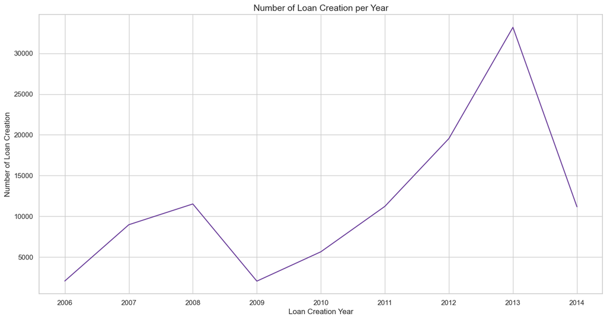

```python
# to group by the years
year_grouped = loan_df['Year'].value_counts().sort_index()
base_color = sns.color_palette("Paired")[9]
plt.figure(figsize= [16, 8])
sns.lineplot(x = year_grouped.index, y = year_grouped, color = base_color)
plt.xlabel('Loan Creation Year', fontsize = 12)
plt.ylabel('Number of Loan Creation', fontsize = 12)
plt.title('Number of Loan Creation per Year', fontsize = 14)
plt.show()
```

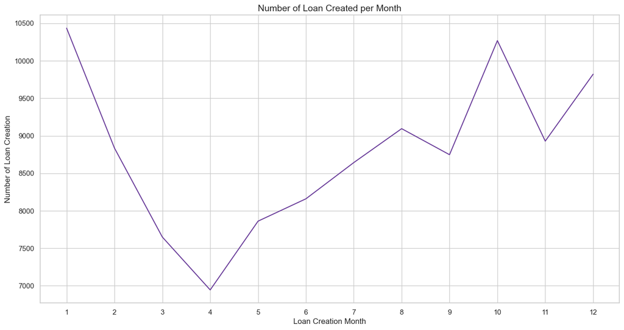

```python
# to group by the years
month_grouped = loan_df['Month'].value_counts().sort_index()
base_color = sns.color_palette("Paired")[9]
plt.figure(figsize= [16, 8])
sns.lineplot(x = month_grouped.index, y = month_grouped, color = base_color)
plt.xlabel('Loan Creation Month', fontsize = 12)
plt.ylabel('Number of Loan Creation', fontsize = 12)
plt.xticks([1,2,3,4,5,6,7,8,9,10,11,12])
plt.title('Number of Loan Created per Month', fontsize = 14)
plt.show()
```

#### Observation:

2013 recorded the year with the highest number of loan creation. On a monthly observation, January has the highest number of loan creation compared to other months

#### Question

What is the relationship between stated monthly income and Loan Original Amount

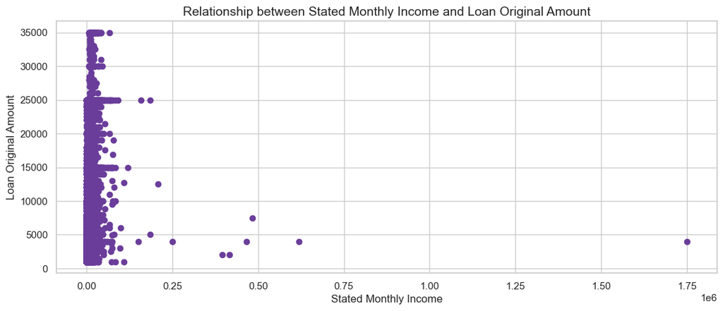

```python
# the visualization
plt.figure(figsize=(13,5))
base_color = sns.color_palette("Paired")[9]

plt.scatter(loan_df['StatedMonthlyIncome'], loan_df['LoanOriginalAmount'], color=base_color)
plt.xlabel('Stated Monthly Income', fontsize = 12)
plt.ylabel('Loan Original Amount', fontsize = 12)
plt.title('Relationship between Stated Monthly Income and Loan Original Amount', fontsize = 14)
plt.show()
```

#### Observation:

No relationship seen in this visual

#### Question:

What is the income range distribution of borrowers in each term?

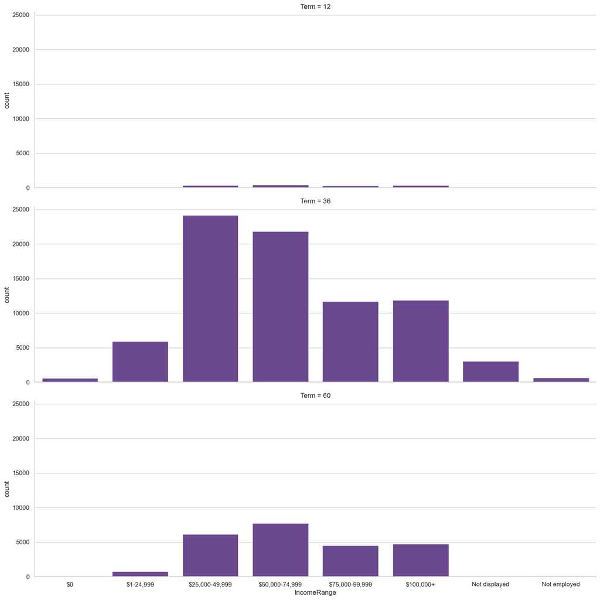

```python
# the visualization
ranges = ["$0", "$1-24,999", "$25,000-49,999", "$50,000-74,999", "$75,000-99,999", "$100,000+", 'Not displayed', 'Not employed']
plt.figure(figsize = [16, 8])
base_color = sns.color_palette("Paired")[9]
sns.catplot(x = 'IncomeRange', data = loan_df, kind = 'count', color = base_color, row = 'Term', height = 5, aspect = 3,
                 order = ranges)
plt.show()
```

#### Observation

The majority of borrowers in the 36-month term fall within the income range of $25,000 - $49,999, whereas those opting for the 60-month term are predominantly in the $50,000 - $74,999 income bracket.

#### Question:

What are the borrowers employment status and which ofnthem are home owners?

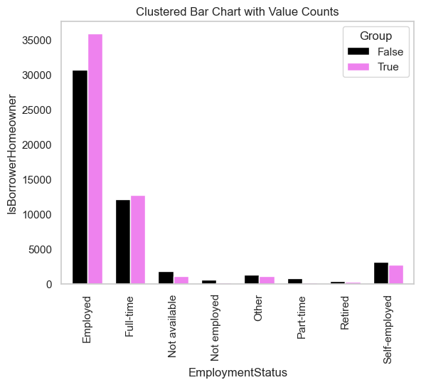

```
IsBorrowerHomeowner
True     54434
False    50959
Name: count, dtype: int64
```

```python
# Create a DataFrame with counts
count_df = loan_df.groupby(['EmploymentStatus', 'IsBorrowerHomeowner']).size().unstack(fill_value=0)

# Plot the clustered bar chart using Seaborn
ax = count_df.plot(kind='bar', stacked=False, width=0.7, color=['black', 'violet'])

# Add labels and title
plt.xlabel('EmploymentStatus')
plt.ylabel('IsBorrowerHomeowner')
plt.title('Clustered Bar Chart with Value Counts')

# Add legend
plt.legend(title='Group')

ax.grid(False, axis='both')

# Show the plot
plt.show()

loan_df['IsBorrowerHomeowner'].value_counts()
```

#### observation

> The predominant demographic among borrowers consists of individuals who are employed and own homes

## Conclusions

The Main Feature of Interest for me was the "Borrowers employment status" and which of them were "House owners". The prevailing demographic within the borrower population comprises individuals who hold employment and possess homeownership.

Main Findings

> In 2013, there were a higher number of loan listings compared to other years. January stood out as the month with the highest recorded loan count.

> Home Owners request for more loan than Borrowers who are not home owners.

> The majority of loan listings pertain to borrowers in the Debt Consolidation category.